# Homework 3

Deanna Springgay

3/16/2021

## Problems

### 4.2

**a)**

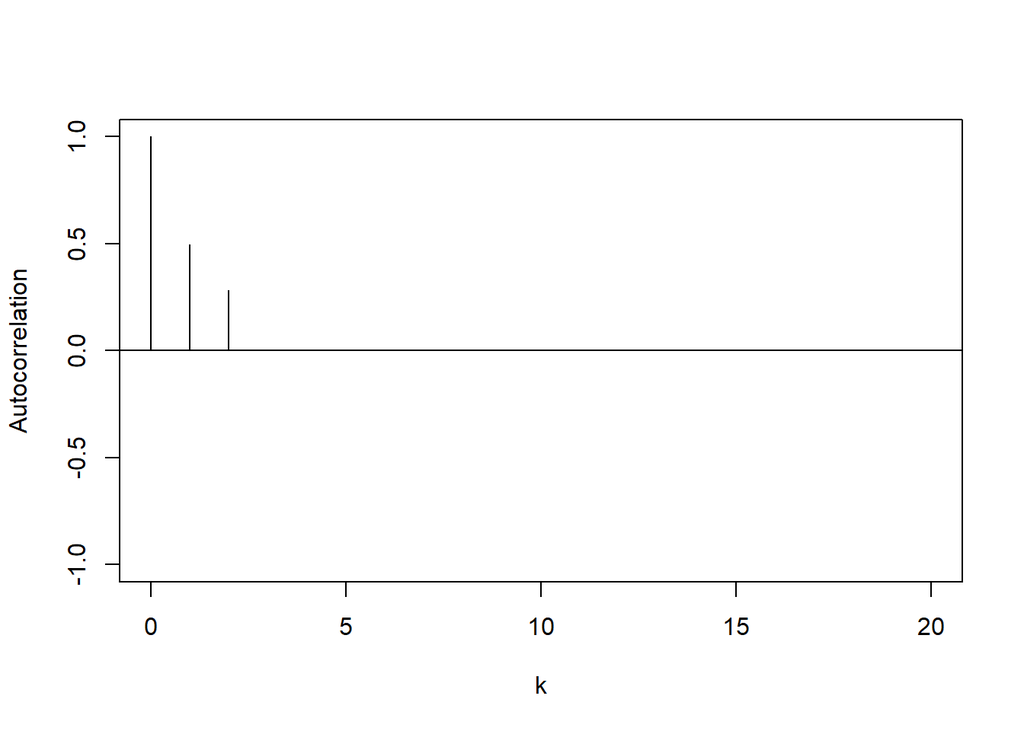

**b)**

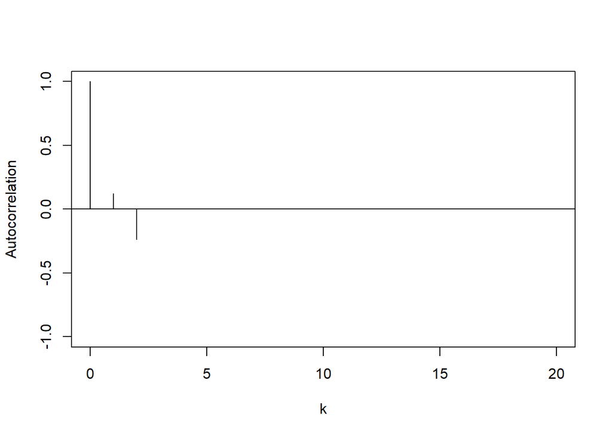

**c)**

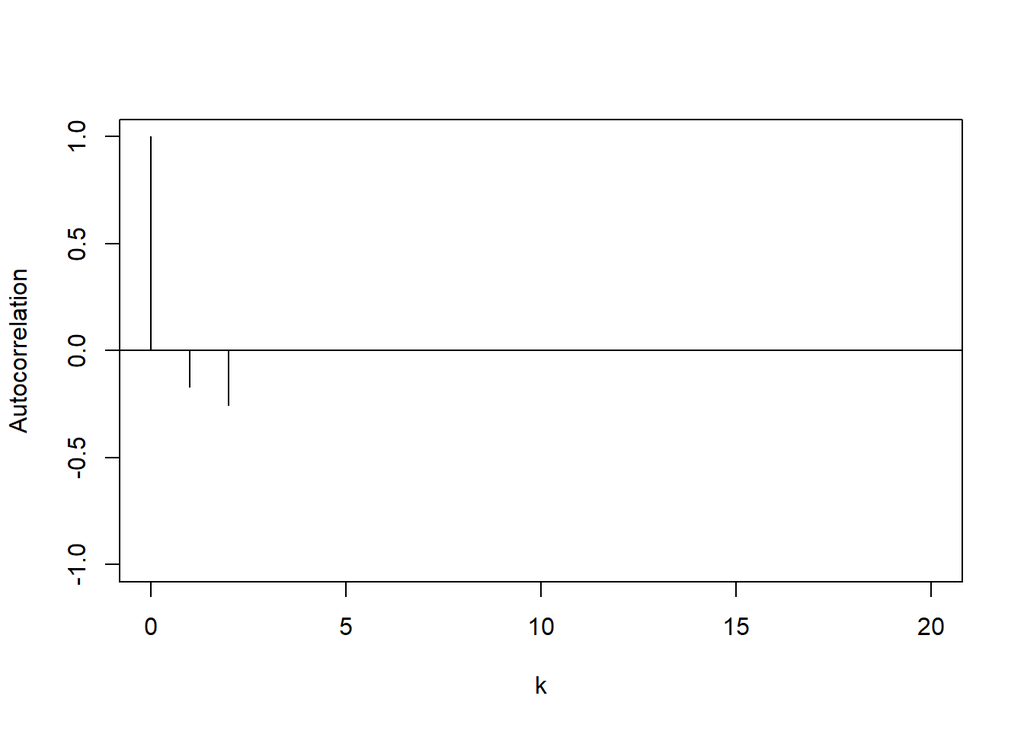

### 4.5

**a)**

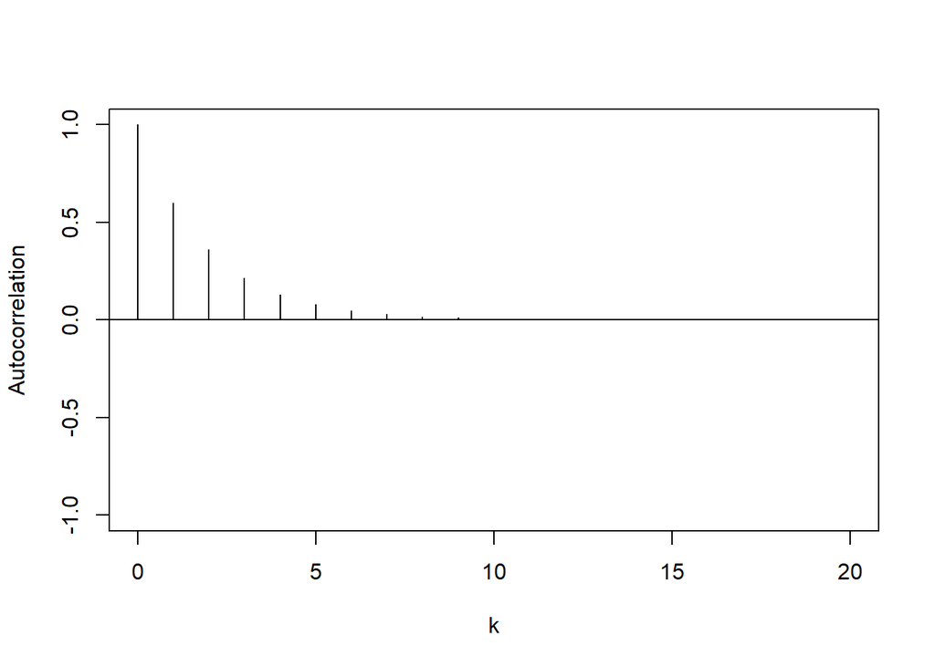

**b)**

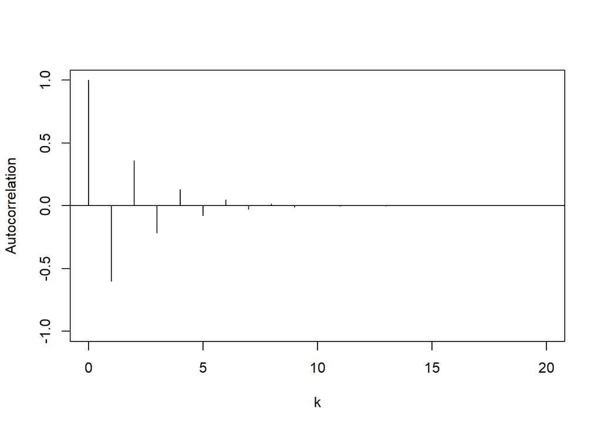

**c)**

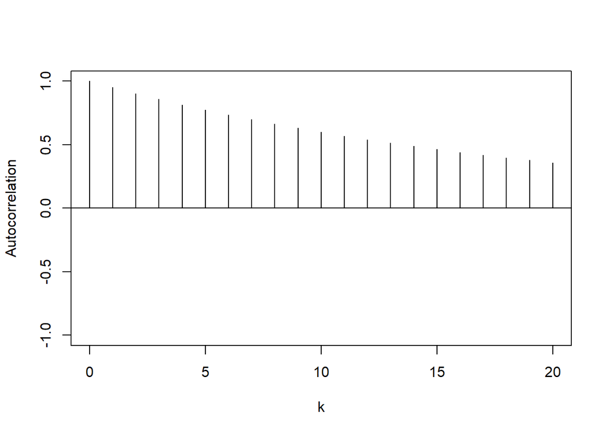

**d)**

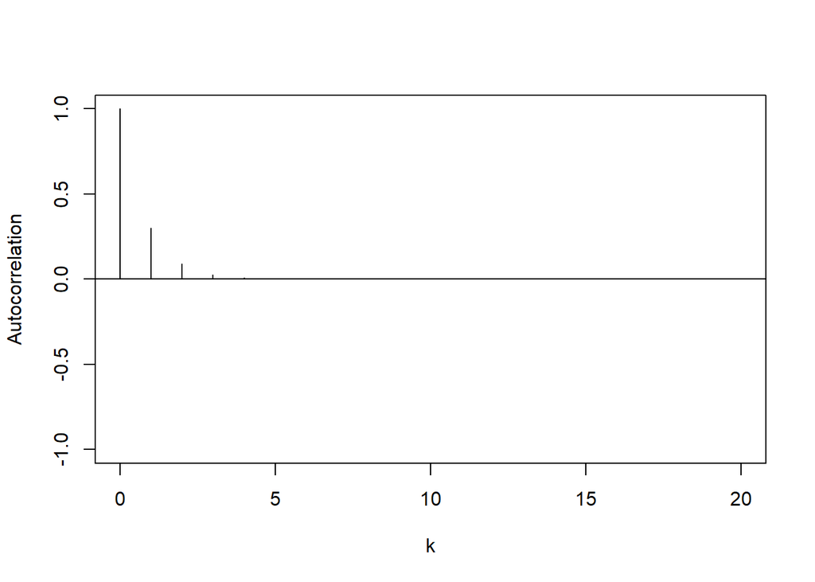

### 4.9

**a)** 0.6 + 0.3 = 0.9 < 1, 0.3 - 0.6 = -0.3 < 1, |0.3| < 1

Therefore, this process is stationary and causal. The roots of the characteristic equation are real.

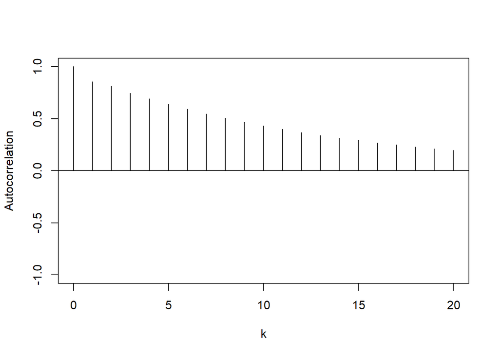

```
## [1]  1.081666-0i -3.081666+0i
```

**b)** -0.4 + 0.5 = 0.1 < 1, 0.5 - -0.4 = 0.9 < 1, |0.5| < 1

Therefore, this process is stationary and causal. The roots of the characteristic equation are real.

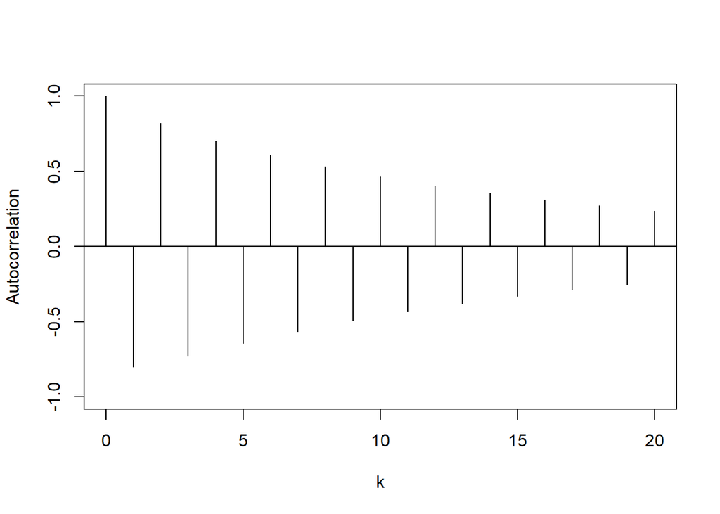

```
## [1] -1.069694+0i  1.869694-0i
```

**c)** 1.2 + -0.7 = 0.5 < 1, -0.7 - 1.2 = -1.9 < 1, |-0.7| < 1

Therefore, this process is stationary and causal. The roots of the characteristic equation are complex.

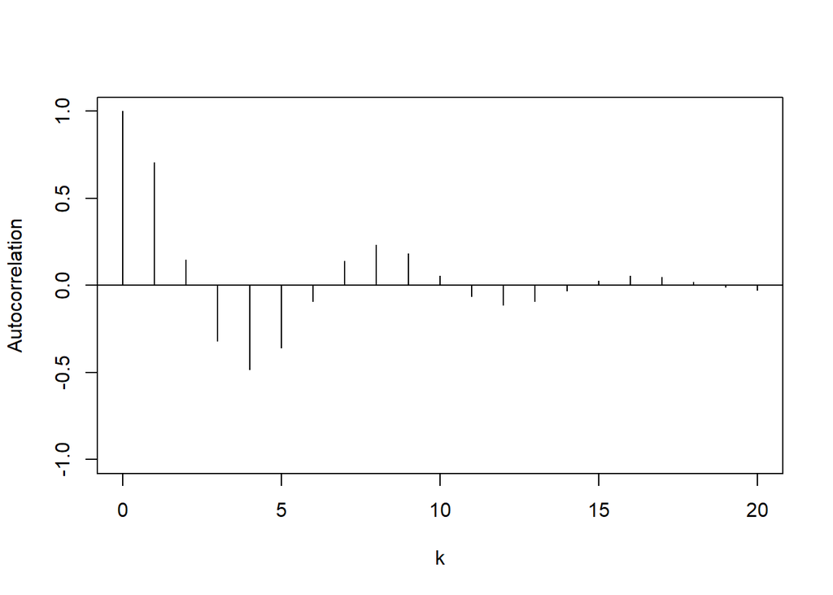

```
## [1] 0.8571429+0.8329931i 0.8571429-0.8329931i
```

**d)** -1 + -0.6 = -1.6 < 1, -0.6 - -1 = 0.4 < 1, |-0.6| < 1

Therefore, this process is stationary and causal. The roots of the characteristic equation are complex.

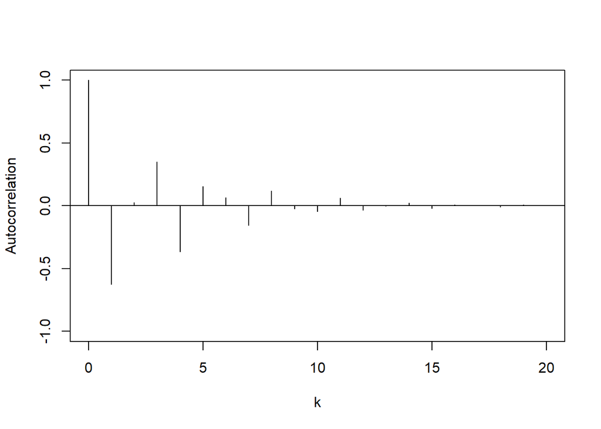

```
## [1] -0.8333333+0.9860133i -0.8333333-0.9860133i
```

**e)** 0.5 + -0.9 = -0.4 < 1, -0.9 - 0.5 = -1.4 < 1, |-0.9| < 1

Therefore, this process is stationary and causal. The roots of the characteristic equation are complex.

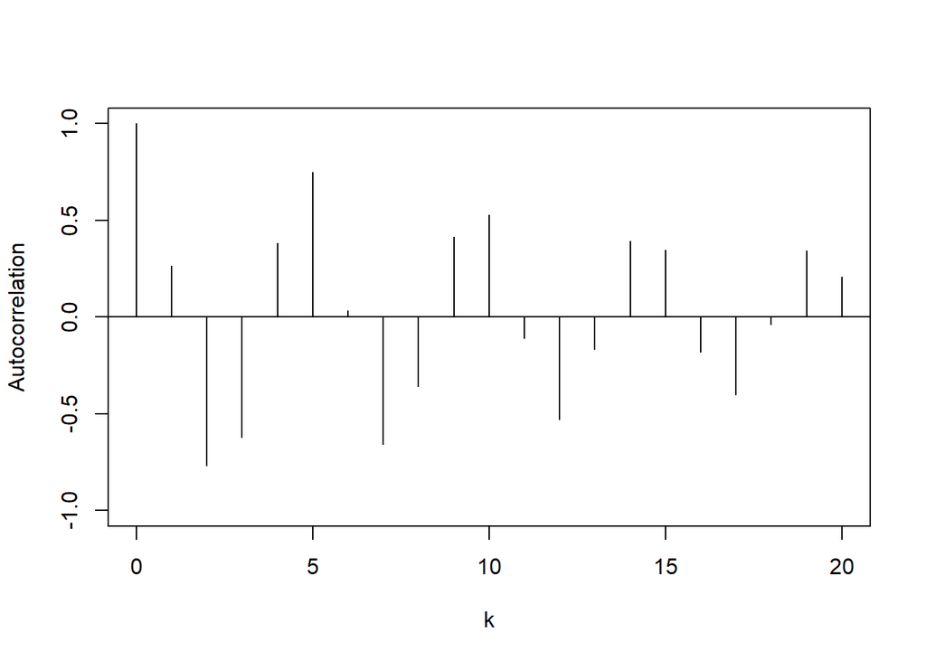

```
## [1] 0.277778+1.016834i 0.277778-1.016834i
```

**f)** -0.5 + -0.6 = -1.1 < 1, -0.6 - -0.5 = -0.1 < 1, |-0.6| < 1

Therefore, this process is stationary and causal. The roots of the characteristic equation are complex.

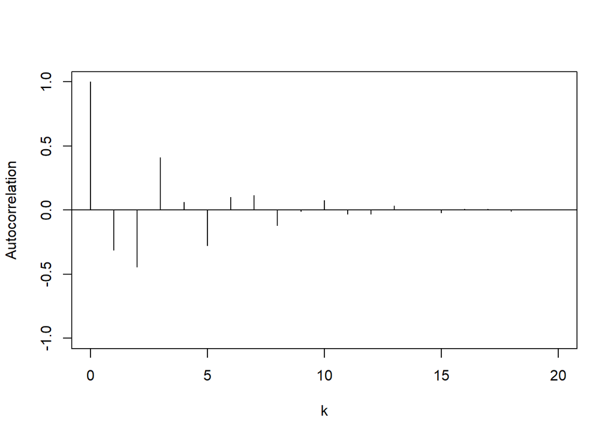

```
## [1] -0.416667+1.221907i -0.416667-1.221907i
```

### 4.19

```r
ARMAacf(ar=-0.5, lag.max=7)
```

```
##          0          1          2          3          4          5          6
##  1.0000000 -0.5000000  0.2500000 -0.1250000  0.0625000 -0.0312500  0.0156250
##          7
## -0.0078125
```

```r
ARMAacf(ma = -c(0.5, -0.25, 0.125, -0.0625, 0.03125, -0.0015625))
```

```
##            0            1            2            3            4            5
##  1.000000000 -0.499669415  0.249157053 -0.123223218  0.058900991 -0.024029260
##            6            7
##  0.001172159  0.000000000
```

### 4.20

This is similar to an ARMA(1,1) with phi = -0.5 and theta = 0.5

```r
ARMAacf(ar = -0.5, ma = -0.5, lag.max = 8)
```

```
##            0            1            2            3            4            5
##  1.000000000 -0.714285714  0.357142857 -0.178571429  0.089285714 -0.044642857
##            6            7            8
##  0.022321429 -0.011160714  0.005580357
```

```r
ARMAacf(ma = -c(1, -0.5, 0.25, -0.125, 0.0625, -0.03125, 0.015625))
```

```
##            0            1            2            3            4            5
##  1.000000000 -0.714240871  0.357015800 -0.178298629  0.088730773 -0.043528304
##            6            7            8
##  0.020089986 -0.006696662  0.000000000
```